# Lab 1 - Gapminder

Author

Brogan Pietrocini

## Task 1

1. Identify, and list here, what aesthetics are being used and which variables are being mapped to each aesthetic.

   The aesthetics being used are: income on x-axis, life_exp on y-axis, size as the population, and color based on the 4 regions.
2. Import the q1data.csv dataset.

```python
#Load Package(s)
from plotnine import *
from numpy import *
from pandas import *
```

```python
#Load in Data
q1data = pd.read_csv(r"C:\Users\broga\OneDrive\Desktop\MSBA\Computing_ML\Labs_Data\Lab_1\q1data.csv")
#Remove Na values
q1data = q1data.dropna()
#Sort data by population so makes points on graph easier to view
q1data = q1data.sort_values(by="population", ascending=False)
#View Data
q1data.head()
```

|  | income | life_exp | population | year | country | four_regions | six_regions | eight_regions | world_bank_region |
| --- | --- | --- | --- | --- | --- | --- | --- | --- | --- |
| 35 | 9690.0 | 75.3 | 1.370000e+09 | 2010 | China | asia | east_asia_pacific | east_asia_pacific | East Asia & Pacific |
| 78 | 4390.0 | 67.6 | 1.230000e+09 | 2010 | India | asia | south_asia | asia_west | South Asia |
| 188 | 54800.0 | 78.9 | 3.090000e+08 | 2010 | United States | americas | america | america_north | North America |
| 79 | 8680.0 | 69.6 | 2.420000e+08 | 2010 | Indonesia | asia | east_asia_pacific | east_asia_pacific | East Asia & Pacific |
| 23 | 15300.0 | 74.0 | 1.960000e+08 | 2010 | Brazil | americas | america | america_south | Latin America & Caribbean |

3. Recreate the plot as best you can using plotnine

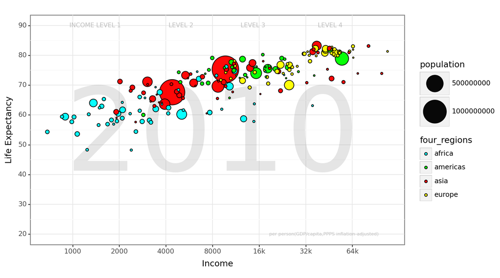

```
<Figure Size: (900 x 500)>
```

```python
#Load Package(s)
from plotnine import *

#assign axis values
xbreak_values = [500, 1000, 2000, 4000, 8000, 16000, 32000, 64000]
xlabel_values = [500, 1000, 2000, 4000, 8000, '16k', '32k', '64k']
ybreak_values = [20, 30, 40, 50, 60, 70, 80, 90]

#Assign fill colors for regions
p1fill_colors = {
    'africa': 'cyan',
    'americas': 'lime',
    'asia': 'r',
    'europe': 'yellow',
}

#Construct Plot
plot1 = (
ggplot(q1data,aes("income","life_exp",fill = "four_regions", size="population"))
+ annotate("text", x=8000, y=52, label="2010",color="grey",size=150,alpha=0.2)
+ annotate("text", x=1400, y=90, label="INCOME LEVEL 1",color="silver",size=8)
+ annotate("text", x=5000, y=90, label="LEVEL 2",color="silver",size=8)
+ annotate("text", x=14600, y=90, label="LEVEL 3",color="silver",size=8)
+ annotate("text", x=46000, y=90, label="LEVEL 4",color="silver",size=8)
+ annotate("text", x=42000, y=20, label="per person(GDP/capita,PPPS inflation-adjusted)",color="silver",size=6)
+ geom_point(alpha=0.97)
+ scale_size([0.5,19])
+ scale_fill_manual(values=p1fill_colors)
+ labs(x='Income',y='Life Expectancy')
+ scale_x_continuous(breaks=xbreak_values,labels = xlabel_values, trans = 'log2')
+ scale_y_continuous(limits = [20,90], breaks = [20, 30, 40, 50, 60, 70, 80, 90])
+ theme_light()
+ theme_bw()
+ theme(figure_size=(9, 5))
      )
#View Plot
plot1
```

4. What other geometries could you use here besides geom_point? Provide an actual plot of another geometry being used here and why it’s good or bad for visualizing these data.

   Another geometry you could use is geom_boxplot which is not as effective for visualizing the data. It is not as effective because the boxplot geometry does not distuinguish the various countries within the four regions as well as the scatter/bubble plot. One bonus of geom_boxplot is that it better represents the quartiles for each region, however, the individual countries are not represented.

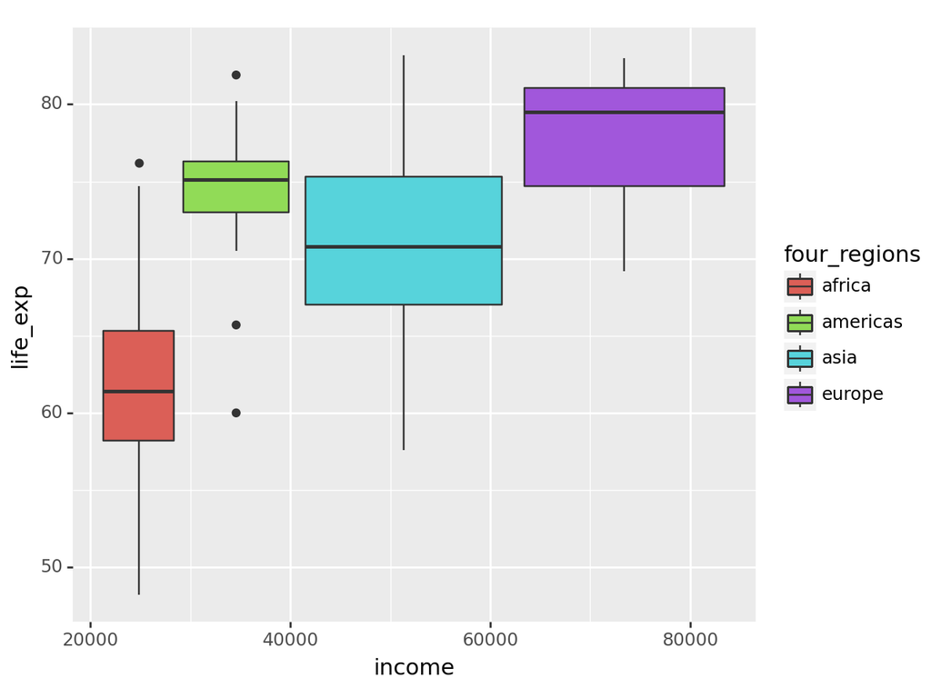

```
<Figure Size: (640 x 480)>
```

```python
plot1b = (ggplot(q1data,aes("income","life_exp", fill = "four_regions", size = "population"))
+ geom_boxplot()
         )
plot1b
```

## Task 2

1. Identify, and list here, what aesthetics are being used and which variables are being mapped to each aesthetic.

   The aesthetics being used are: exports on the x-axis, imports on y-axis, size as the energy variable, and color based on the 4 regions.
2. Import the q2data.csv dataset.

```python
#Load in Data
q2data = pd.read_csv(r"C:\Users\broga\OneDrive\Desktop\MSBA\Computing_ML\Labs_Data\Lab_1\q2data.csv")
#Remove Na values
q2data = q2data.dropna()
#View Data
q2data.head()
```

|  | imports | exports | energy | year | country | four_regions | six_regions | eight_regions | world_bank_region |
| --- | --- | --- | --- | --- | --- | --- | --- | --- | --- |
| 1 | 36.7 | 11.5 | 427.0 | 1997 | Albania | europe | europe_central_asia | europe_east | Europe & Central Asia |
| 2 | 22.5 | 22.6 | 825.0 | 1997 | Algeria | africa | middle_east_north_africa | africa_north | Middle East & North Africa |
| 6 | 12.9 | 10.4 | 1660.0 | 1997 | Argentina | americas | america | america_south | Latin America & Caribbean |
| 7 | 52.8 | 19.0 | 610.0 | 1997 | Armenia | europe | europe_central_asia | europe_east | Europe & Central Asia |
| 9 | 20.5 | 19.6 | 5550.0 | 1997 | Australia | asia | east_asia_pacific | east_asia_pacific | East Asia & Pacific |

3. Recreate the plot as best you can using plotnine.

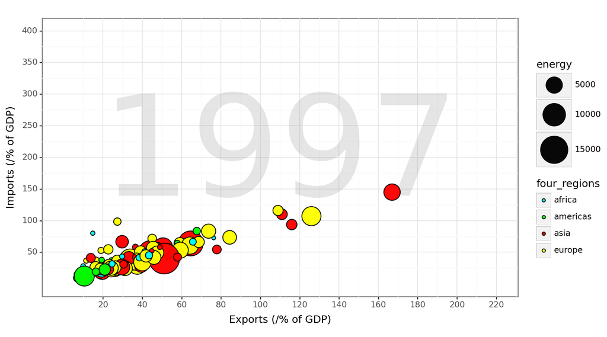

```
<Figure Size: (900 x 500)>
```

```python
#Load Package(s)
from plotnine import *
from pandas import to_numeric
#Assign fill colors for regions
p2fill_colors = {
    'africa': 'cyan',
    'americas': 'lime',
    'asia': 'r',
    'europe': 'yellow',
}

#Change energy to a numeric variable
q2data["energy"] = to_numeric(q2data["energy"])

#Construct Plot
plot2 = (
ggplot(q2data,aes("exports","imports",fill = "four_regions", size = "energy"))
+ annotate("text", x=110, y=200, label="1997",color="grey",size=150,alpha=0.2)
+ geom_point(alpha=0.97)
+ scale_size([0.5,18])
+ scale_fill_manual(values=p2fill_colors)
+ labs(x='Exports (/% of GDP)',y='Imports (/% of GDP)')
+ scale_x_continuous(limits = [0,220], breaks = [20, 40, 60, 80, 100, 120, 140, 160, 180, 200, 220])
+ scale_y_continuous(limits = [0,400], breaks = [50, 100, 150, 200, 250, 300, 350, 400])
+ theme_light()
+ theme_bw()
+ theme(figure_size=(9, 5))
      )
#View Plot
plot2
```

4. What other geometries could you use here besides geom_point? Provide an actual plot of another geometry being used here and why it’s good or bad for visualizing these data.

   Other geometries you could use involve geom_violin which is not as effective for visualizing the data. It is not as effective because the violin geometry does not distinguish the various countries like the boxplot geometry, and also requires non overlapping x-intervals which does not comply with the data.

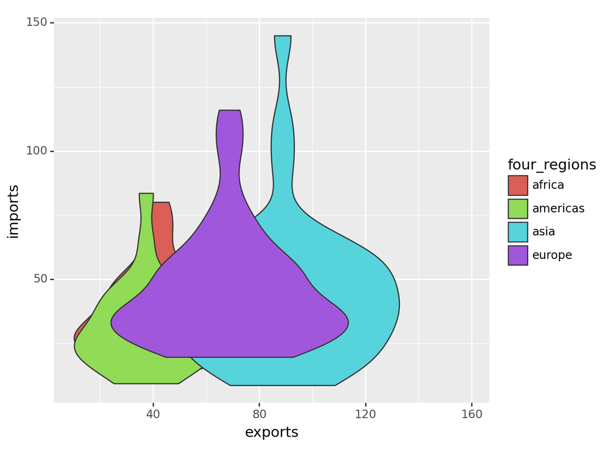

```
<Figure Size: (640 x 480)>
```

```python
plot2b = (
ggplot(q2data,aes("exports","imports",fill = "four_regions", size = "energy"))
+ geom_violin()
)
plot2b
```

## Task 3

1. Identify, and list here, what aesthetics are being used and which variables are being mapped to each aesthetic.

   The aesthetics being used are: internet_users on the x-axis, gdp on y-axis, size as the income variable, and color based on the 4 regions.
2. Import the q3data.csv dataset.

```python
#Load in Data
q3data = pd.read_csv(r"C:\Users\broga\OneDrive\Desktop\MSBA\Computing_ML\Labs_Data\Lab_1\q3data.csv")
#Remove Na values
q3data = q3data.dropna()
#View Data
q3data.head()
```

|  | internet_users | gdp | income | year | country | four_regions | six_regions | eight_regions | world_bank_region |
| --- | --- | --- | --- | --- | --- | --- | --- | --- | --- |
| 0 | 0.00456 | 330.0 | 1190.0 | 2001 | Afghanistan | asia | south_asia | asia_west | South Asia |
| 1 | 0.39000 | 2570.0 | 6780.0 | 2001 | Albania | europe | europe_central_asia | europe_east | Europe & Central Asia |
| 2 | 1.59000 | 3770.0 | 9230.0 | 2001 | Algeria | africa | middle_east_north_africa | africa_north | Middle East & North Africa |
| 4 | 11.30000 | 42600.0 | 35600.0 | 2001 | Andorra | europe | europe_central_asia | europe_west | Europe & Central Asia |
| 5 | 0.27000 | 2440.0 | 2900.0 | 2001 | Angola | africa | sub_saharan_africa | africa_sub_saharan | Sub-Saharan Africa |

3. Recreate the plot as best you can using plotnine.

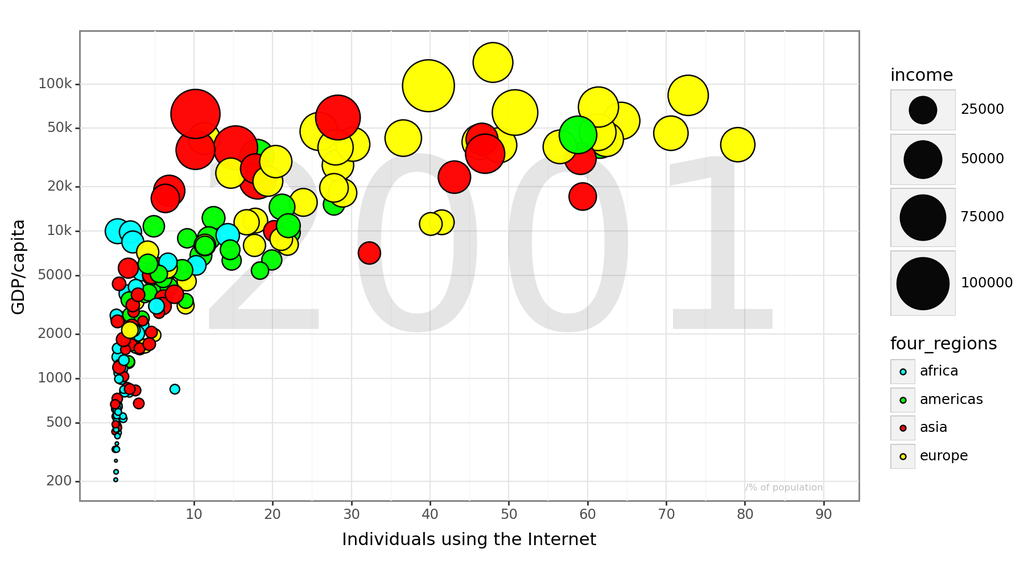

```
<Figure Size: (900 x 500)>
```

```python
#Load Package(s)
from plotnine import *

#Assign fill colors for regions
p3fill_colors = {
    'africa': 'cyan',
    'americas': 'lime',
    'asia': 'r',
    'europe': 'yellow',
}

#Construct Plot
plot3 = (
ggplot(q3data,aes("internet_users","gdp",fill = "four_regions", size = "income"))
+ annotate("text", x=48, y=6000, label="2001",color="grey",size=150,alpha=0.2)
+ annotate("text", x=85, y=180, label="/% of population",color="silver",size=6)
+ geom_point(alpha=0.97)
+ scale_size([0.5,18])
+ scale_fill_manual(values=p3fill_colors)
+ labs(x='Individuals using the Internet',y='GDP/capita')
+ scale_x_continuous(limits = [0,90],
                     breaks = [10, 20, 30, 40, 50, 60, 70, 80, 90])
+ scale_y_continuous(limits = [0,230000],
                     breaks = [200, 500, 1000, 2000, 5000, 10000, 20000, 50000, 100000],
                     labels = [200, 500, 1000, 2000, 5000, '10k', '20k', '50k', '100k'],
                     trans = 'log2')
+ theme_light()
+ theme_bw()
+ theme(figure_size=(9, 5))
      )
#View Plot
plot3
```

4. What other geometries could you use here besides geom_point? Provide an actual plot of another geometry being used here and why it’s good or bad for visualizing these data.

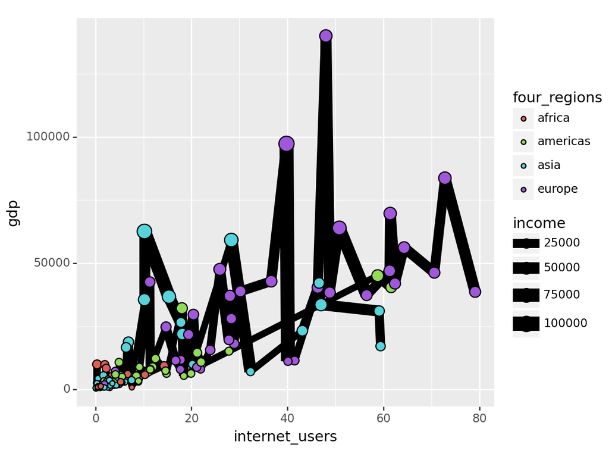

```
<Figure Size: (640 x 480)>
```

```python
plot3b = (
ggplot(q3data,aes("internet_users","gdp",fill = "four_regions", size = "income"))
+ geom_line()
+ geom_point()
)
plot3b
```